# Issue #72: RDDアプローチで弾力性を推定したい

加藤 大貴

Latest update: 2021/7/8

# Issue #72: RDDアプローチで弾力性を推定したい

[リンク](https://github.com/KatoPachi/NASTAB/issues/72#issue-909426778)

## セットアップ：パッケージとggplot2のテンプレート

パッケージのロード

```r
library(xfun)
xfun::pkg_attach2(c("readstata13", "tidyverse", "rlist", "patchwork"))
xfun::pkg_attach2(c("plm", "lmtest", "sandwich", "lfe", "Formula"))
xfun::pkg_attach2("kableExtra")
source("../script/R/00-analysis_functions.r")
```

以下、ggplot2のテンプレート

```r
my_theme <- theme_minimal() +
  theme(
    # setting: background
    plot.background = element_rect(
      #fill="#87CEEB50",
      color = "transparent"
    ),

    # setting: plot
    panel.border = element_rect(color = "white", fill = NA),
    panel.background = element_rect(fill = "white"),
    panel.grid = element_line(color = "grey80"),
    panel.grid.major.x = element_blank(),
    panel.grid.minor.x = element_blank(),
    panel.grid.minor.y = element_blank(),

    # setting: text
    plot.title = element_text(hjust = 0.5, size = 20),
    plot.caption = element_text(size = 11),

    # setting: axis
    axis.text = element_text(color = "black", size = 13),
    axis.title = element_text(size = 13),
    axis.ticks.length = unit(0.25, "cm"),
    axis.ticks.x = element_line(),
    axis.ticks.y = element_line(),
    axis.line = element_line(),

    # setting: legend
    legend.title = element_text(size = 12),
    legend.text = element_text(size = 12),
    legend.key.size = unit(0.5, "cm"),
    #legend.background = element_rect(color = "black"),
    legend.position = "bottom"
  )
```

## データの読み込み

1. `mtrdt.csv`の所得税率(`MTR`)から寄付の相対価格(`price`)を作成
2. 一段低い寄付価格ブラケットの最低所得（`lower_income_10000won`）を`to_next_price`とする
3. ナスタブデータとマージして、一段低い寄付価格ブラケットに移動するために必要な寄付額（`dist_to_next_price`）を作成
   - `dist_to_next_price = to_next_price - lincome`

```r
mtrdt <- read_csv("../data/origin/mtrdt.csv") %>%
  mutate(price = 1 - MTR) %>%
  arrange(year, lower_income_10000won) %>%
  group_by(year) %>%
  mutate(to_next_price = dplyr::lead(lower_income_10000won))

df <- read.dta13("../data/shaped.dta") %>%
  data.frame() %>%
  mutate(
    log_price = log(price),
    log_lprice = log(lprice),
    log_iv1price = log(iv1price),
    log_iv2price = log(iv2price),
    log_iv3price = log(iv3price),
    log_total_g = log(i_total_giving + 1),
    log_pinc_all = log(lincome + 100000),
  ) %>%
  filter(year >= 2012 & age >= 24) %>%
  mutate(price = round(price, 2)) %>%
  left_join(mtrdt, by = c("year", "price")) %>%
  mutate(dist_to_next_price = to_next_price - lincome)
```

以下に2012年と2013年の所得税率と寄付価格に関する情報を示しておく

```r
mtrdt %>% dplyr::filter(year == 2012 | year == 2013)
```

```
## # A tibble: 10 x 5
## # Groups:   year [2]
##     year lower_income_10000won   MTR price to_next_price
##    <dbl>                 <dbl> <dbl> <dbl>         <dbl>
##  1  2012                     0  0.06  0.94          1200
##  2  2012                  1200  0.15  0.85          4600
##  3  2012                  4600  0.24  0.76          8800
##  4  2012                  8800  0.35  0.65         30000
##  5  2012                 30000  0.38  0.62            NA
##  6  2013                     0  0.06  0.94          1200
##  7  2013                  1200  0.15  0.85          4600
##  8  2013                  4600  0.24  0.76          8800
##  9  2013                  8800  0.35  0.65         30000
## 10  2013                 30000  0.38  0.62            NA
```

## 課税前所得と課税後所得の密度分布

所得税ブラケットの境界線で密度が著しく上昇しているかどうかを目視で確認する（Bunching）

- 12000Kウォンの境界線の若干右側で密度が高くなるが、スムーズな動きをしているように見える
- 46000Kウォンと88000Kウォンでも密度関数が境界線上で著しく跳ね上がるような動きをしていない

所得によるBunchingは見られない。サーベイ調査だからか？

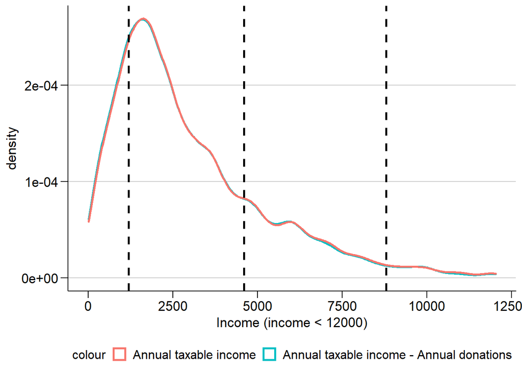

```r
df %>%
  dplyr::filter(year < 2014 & lincome - i_total_giving > 0) %>%
  mutate(segment = round(lincome / 100, 0) * 100) %>%
  dplyr::filter(segment <= 12000) %>%
  ggplot() +
    # geom_histogram(binwidth = 100, color = "black", fill = "grey80") +
    geom_density(
      aes(
        x = (lincome - i_total_giving),
        color = "Annual taxable income - Annual donations"),
      size = 1) +
    geom_density(aes(x = lincome, color = "Annual taxable income"), size = 1) +
    geom_vline(aes(xintercept = 1200), linetype = 2, size = 1) +
    geom_vline(aes(xintercept = 4600), linetype = 2, size = 1) +
    geom_vline(aes(xintercept = 8800), linetype = 2, size = 1) +
    labs(x = "Income (income < 12000)") +
    my_theme
```

## 所得と寄付の相関図

境界線上で寄付額が非連続に増加（もしくは減少）しているならば、そのRDD効果を推定することで寄付の弾性値を推測できる

- 1000ウォン区間を作成し、各区間の寄付の対数値の平均をプロット
- 2012年と2013年をまとめてプロット

結果として、ブラケットの境界線上で寄付額の対数値平均がジャンプしているようなことはないと見える

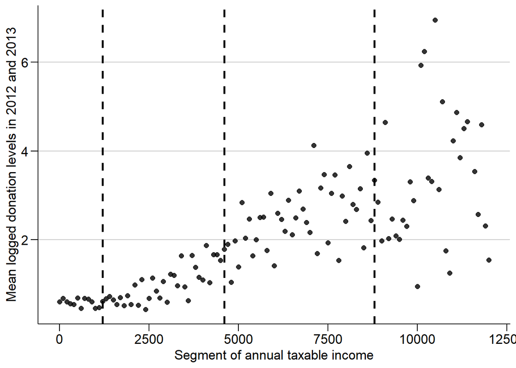

```r
df %>%
  dplyr::filter(year < 2014) %>%
  mutate(segment = round(lincome / 100, 0) * 100) %>%
  group_by(segment) %>%
  summarize(mean = mean(log_total_g, na.rm = TRUE)) %>%
  dplyr::filter(segment <= 12000) %>%
  ggplot(aes(x = segment, y = mean)) +
    geom_point(size = 2, alpha = 0.8) +
    geom_vline(aes(xintercept = 1200), linetype = 2, size = 1) +
    geom_vline(aes(xintercept = 4600), linetype = 2, size = 1) +
    geom_vline(aes(xintercept = 8800), linetype = 2, size = 1) +
    labs(
      x = "Segment of annual taxable income",
      y = "Mean logged donation levels in 2012 and 2013") +
    my_theme
```

## Next lower blacketと寄付額の相関

1段階安い寄付価格に移動するために必要な寄付額と実際の寄付額の関係を確認する

- 寄付額の操作のインセンティブはbracketのボーダーまでの距離で異なるかを確認する

以下の図は2つのパネルで構成されている

- パネルAはすべてのブラケットのデータを用いてプロットしたもの
- パネルBは各ブラケットにサンプルを分割してプロットしたもの
- ボーダーまでの距離を100ウォン単位で分割し、その平均寄付額をプロットしている
- 点線の左側の領域は、1段階安い寄付価格ブラケットに移動できるだけの寄付をしている

結果

- ボーダーまでの距離が2000Kウォン以内の人以外はブラケットに移動するのに十分な寄付をしていない
- パネルAをみると、正の相関をしているように見えるが、これは所得効果によるものと考えられる
  - ボーダーまでの距離が100000Kウォンを超える人の所得は最低でも88000Kウォンであるから
- 課税前のブラケットの寄付価格が0.76のブラケットは負の相関をしている（ように見える）

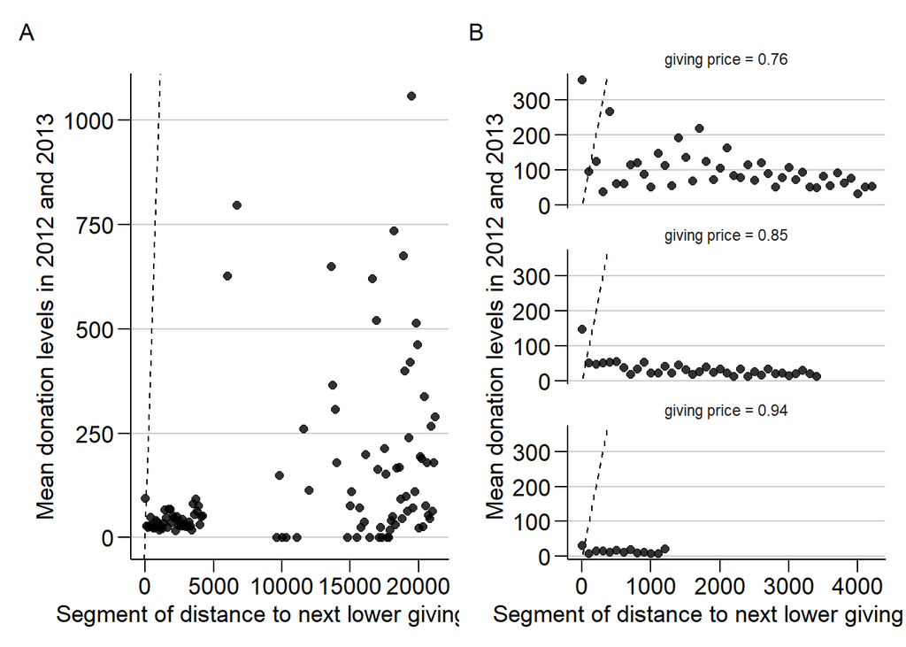

```r
full <- df %>%
  dplyr::filter(0.62 < price & year < 2014) %>%
  mutate(segment = round(dist_to_next_price / 100, 0) * 100) %>%
  group_by(segment) %>%
  summarize(mean = mean(i_total_giving, na.rm = TRUE)) %>%
  ggplot(aes(x = segment, y = mean)) +
    geom_point(size = 2, alpha = 0.8) +
    geom_abline(aes(intercept = 0, slope = 1), linetype = 2) +
    my_theme

sub <- df %>%
  dplyr::filter(0.65 < price & year < 2014) %>%
  mutate(segment = round(dist_to_next_price / 100, 0) * 100) %>%
  group_by(price, segment) %>%
  summarize(mean = mean(i_total_giving, na.rm = TRUE)) %>%
  ungroup() %>%
  mutate(price = factor(
    price, labels = sprintf("giving price = %1.2f", unique(price))
  )) %>%
  ggplot(aes(x = segment, y = mean)) +
    geom_point(size = 2, alpha = 0.8) +
    geom_abline(aes(intercept = 0, slope = 1), linetype = 2) +
    facet_wrap(~price, ncol = 1) +
    my_theme

(full + sub) &
  labs(
    x = "Segment of distance to next lower giving price",
    y = "Mean donation levels in 2012 and 2013") &
  plot_annotation(tag_levels = "A")
```

## Next lower blacketによる寄付額の回帰分析

上図の結果を回帰モデルを使って統計的に有意なものであるかを確認する
$$\text{i_total_giving}_{it} = \beta + \text{dist_to_next_price} + \gamma X_{it} + \mu_i + \eta_t + \epsilon_{it}$$

```r
distregs <- list(
  reg1 = i_total_giving ~ dist_to_next_price + log_pinc_all | 0 | 0 | pid,
  reg2 = i_total_giving ~ dist_to_next_price + log_pinc_all | year | 0 | pid,
  reg3 = i_total_giving ~ dist_to_next_price + log_pinc_all |
    year + pid | 0 | pid,
  reg4 = log_total_g ~ log(dist_to_next_price) + log_pinc_all +
    age + sqage + factor(year):factor(educ) + factor(year):factor(gender) +
    factor(year):factor(living_area) | year + pid | 0 | pid
)

covnote <- tribble(
  ~vars, ~stat, ~reg1, ~reg2, ~reg3, ~reg4,
  "Individual FE", "vars", "N", "N", "Y", "Y",
  "Time FE", "vars", "N", "Y", "Y", "Y",
  "Other covariates", "vars", "N", "N", "N", "Y"
)

est_distregs <- distregs %>%
  purrr::map(~felm(., data = df %>% dplyr::filter(year < 2014)))
est_distregs_int <- distregs %>%
  purrr::map(
    ~felm(., data = df %>% dplyr::filter(year < 2014 & i_ext_giving == 1))
  )
est_distregs_ext <- distregs %>%
  purrr::map(~update(as.Formula(.), i_ext_giving ~ .)) %>%
  purrr::map(~felm(., data = df %>% dplyr::filter(year < 2014)))
```

2012年と2013年のサンプルを用いた結果、Next lower blacketまでの距離と寄付額に相関はない

```r
fullset_tab(est_distregs, keep_coef = "dist_to_next_price")$set %>%
  bind_rows(covnote) %>%
  mutate_at(
    c("reg1", "reg2", "reg3", "reg4"), list(~ifelse(is.na(.), "", .))
  ) %>%
  dplyr::select(-stat) %>%
  kable(
    title = "Full sample",
    col.names = c("", sprintf("(%1d)", 1:4)),
    align = "lcccc",
    format = "html"
  ) %>%
  add_header_above(
   c("", "Giving amount" = 3, "log(Giving amount)" = 1),
   escape = FALSE
  )
```

Giving amount

log(Giving amount)

dist_to_next_price

0.002

0.002

-0.000

dist_to_next_price

(0.001)

(0.001)

(0.001)

log(dist_to_next_price)

0.008

log(dist_to_next_price)

(0.027)

N

14695

14695

14695

14695

R-squared

0.044

0.044

0.813

0.809

Adjusted R-squared

0.043

0.043

0.590

0.579

Individual FE

N

N

Y

Y

Time FE

N

Y

Y

Y

Other covariates

N

N

N

Y

2012年と2013年かつ寄付した人のみに限定すると、正の相関が確認できる。 しかし、個人固定効果を取ると、その相関がなくなる（やはりあまり関係がないか）

```r
fullset_tab(est_distregs_int, keep_coef = "dist_to_next_price")$set %>%
  bind_rows(covnote) %>%
  mutate_at(
    c("reg1", "reg2", "reg3", "reg4"), list(~ ifelse(is.na(.), "", .))
  ) %>%
  dplyr::select(-stat) %>%
  kable(
    title = "Intentisive margin (Those who give)",
    col.names = c("", sprintf("(%1d)", 1:4)),
    align = "lcccc",
    format = "html"
  ) %>%
  add_header_above(
    c("", "Giving amount" = 3, "log(Giving amount)" = 1),
    escape = FALSE
  )
```

Giving amount

log(Giving amount)

dist_to_next_price

0.006**

0.006**

-0.001

dist_to_next_price

(0.003)

(0.003)

(0.002)

log(dist_to_next_price)

0.016

log(dist_to_next_price)

(0.032)

N

3057

3057

3057

3057

R-squared

0.026

0.026

0.913

0.938

Adjusted R-squared

0.025

0.025

0.702

0.780

Individual FE

N

N

Y

Y

Time FE

N

Y

Y

Y

Other covariates

N

N

N

Y

2012年と2013年にサンプルを限定し、寄付したかどうかを示すダミー変数をアウトカム変数とした その結果、個人固定効果を取ると負の相関が統計的に非有意となる（やはり関係ない？）

```r
fullset_tab(est_distregs_ext, keep_coef = "dist_to_next_price")$set %>%
  bind_rows(covnote) %>%
  mutate_at(
    c("reg1", "reg2", "reg3", "reg4"), list(~ ifelse(is.na(.), "", .))
  ) %>%
  dplyr::select(-stat) %>%
  kable(
    title = "Extensive margin (Whether to give)",
    col.names = c("", sprintf("(%1d)", 1:4)),
    align = "lcccc",
    format = "html"
  ) %>%
  add_header_above(
    c("", "1 = Giving" = 4),
    escape = FALSE
  )
```

1 = Giving

dist_to_next_price

-0.000***

-0.000***

-0.000

dist_to_next_price

(0.000)

(0.000)

(0.000)

log(dist_to_next_price)

-0.001

log(dist_to_next_price)

(0.006)

N

14695

14695

14695

14695

R-squared

0.078

0.078

0.780

0.782

Adjusted R-squared

0.078

0.078

0.518

0.519

Individual FE

N

N

Y

Y

Time FE

N

Y

Y

Y

Other covariates

N

N

N

Y

## Last-price elasticity with IV

### Reminder

Last priceの弾力性を推定するIVモデルの結果をリマインドしておく

```r
lpregs <- list(
  reg1 = log_total_g ~ log_pinc_all |
    year + pid | (log_lprice ~ log_price) | pid,
  reg2 = log_total_g ~ log_pinc_all + age + sqage |
    year + pid | (log_lprice ~ log_price) | pid,
  reg3 = log_total_g ~ log_pinc_all + age + sqage + factor(year):factor(educ) |
    year + pid | (log_lprice ~ log_price) | pid,
  reg4 = log_total_g ~ log_pinc_all + age + sqage + factor(year):factor(educ) +
    factor(year):factor(gender) |
    year + pid | (log_lprice ~ log_price) | pid,
  reg5 = log_total_g ~ log_pinc_all + age + sqage + factor(year):factor(educ) +
    factor(year):factor(gender) + factor(year):factor(living_area) |
    year + pid | (log_lprice ~ log_price) | pid
)

covnote2 <- tribble(
  ~vars, ~stat, ~reg1, ~reg2, ~reg3, ~reg4, ~reg5,
  "Individual FE", "vars", "Y", "Y", "Y", "Y", "Y",
  "Time FE", "vars", "Y", "Y", "Y", "Y", "Y",
  "Age", "vars", "N", "Y", "Y", "Y", "Y",
  "Year x Education", "vars", "N", "N", "Y", "Y", "Y",
  "Year x Gender", "vars", "N", "N", "N", "Y", "Y",
  "Year x Resident Area", "vars", "N", "N", "N", "N", "Y"
)
```

```r
est_lpregs <- lpregs %>% purrr::map(~ felm(., data = df))

fullset_tab(est_lpregs, keep_coef = "log_lprice")$set %>%
  bind_rows(covnote2) %>%
  mutate(vars = if_else(stat == "se", "", vars)) %>%
  dplyr::select(-stat) %>%
  kable(
    title = "Full sample",
    col.names = c("", sprintf("(%1d)", 1:5)),
    align = "lccccc",
    format = "html"
  ) %>%
  add_header_above(
   c("", "log(Giving amount)" = 5),
   escape = FALSE
  )
```

log(Giving amount)

`log_lprice(fit)`

-2.421***

-2.536***

-2.750***

-2.529***

-2.650***

(0.204)

(0.216)

(0.233)

(0.231)

(0.229)

N

52304

52304

52302

52302

52302

R-squared

0.619

0.619

0.620

0.620

0.624

Adjusted R-squared

0.529

0.529

0.529

0.530

0.533

Individual FE

Y

Y

Y

Y

Y

Time FE

Y

Y

Y

Y

Y

Age

N

Y

Y

Y

Y

Year x Education

N

N

Y

Y

Y

Year x Gender

N

N

N

Y

Y

Year x Resident Area

N

N

N

N

Y

```r
est_lpregs_int <- lpregs %>%
  purrr::map(
    ~felm(., data = df %>% dplyr::filter(i_ext_giving == 1))
  )

fullset_tab(est_lpregs_int, keep_coef = "log_lprice")$set %>%
  bind_rows(covnote2) %>%
  mutate(vars = if_else(stat == "se", "", vars)) %>%
  dplyr::select(-stat) %>%
  kable(
    title = "Intentive margin (Those who give)",
    col.names = c("", sprintf("(%1d)", 1:5)),
    align = "lccccc",
    format = "html"
  ) %>%
  add_header_above(
   c("", "log(Giving amount)" = 5),
   escape = FALSE
  )
```

log(Giving amount)

`log_lprice(fit)`

-0.898***

-0.961***

-1.197***

-0.998***

-1.074***

(0.270)

(0.271)

(0.307)

(0.325)

(0.332)

N

10672

10672

10672

10672

10672

R-squared

0.791

0.792

0.792

0.793

0.798

Adjusted R-squared

0.671

0.671

0.672

0.672

0.674

Individual FE

Y

Y

Y

Y

Y

Time FE

Y

Y

Y

Y

Y

Age

N

Y

Y

Y

Y

Year x Education

N

N

Y

Y

Y

Year x Gender

N

N

N

Y

Y

Year x Resident Area

N

N

N

N

Y

```r
est_lpregs_ext <- lpregs %>%
  purrr::map(~ update(as.Formula(.), i_ext_giving ~ .)) %>%
  purrr::map(~ felm(., data = df))

fullset_tab(est_lpregs_ext, keep_coef = "log_lprice")$set %>%
  bind_rows(covnote2) %>%
  mutate(vars = if_else(stat == "se", "", vars)) %>%
  dplyr::select(-stat) %>%
  kable(
    title = "Extensive margin (Whether to give)",
    col.names = c("", sprintf("(%1d)", 1:5)),
    align = "lccccc",
    format = "html"
  ) %>%
  add_header_above(
   c("", "1 = Give" = 5),
   escape = FALSE
  )
```

1 = Give

`log_lprice(fit)`

-0.623***

-0.630***

-0.644***

-0.593***

-0.619***

(0.046)

(0.049)

(0.053)

(0.052)

(0.052)

N

52304

52304

52302

52302

52302

R-squared

0.567

0.567

0.567

0.568

0.572

Adjusted R-squared

0.464

0.464

0.464

0.465

0.469

Individual FE

Y

Y

Y

Y

Y

Time FE

Y

Y

Y

Y

Y

Age

N

Y

Y

Y

Y

Year x Education

N

N

Y

Y

Y

Year x Gender

N

N

N

Y

Y

Year x Resident Area

N

N

N

N

Y

### Last price with ivにdistance to next lower blacketをダイレクトにコントロールする

next lower blacketまでの距離を共変量としてコントールしてLast priceの弾力性を推定する ただし、2014年以降のtax credit制度ではこの問題は生じないので、 `dist_to_next_price = 0`とした

```r
df2 <- df %>%
  mutate(dist_to_next_price = if_else(year >= 2014, 0, dist_to_next_price))
```

```r
est_lpregs2 <- lpregs %>%
  purrr::map(~update(as.Formula(.), . ~ . + dist_to_next_price)) %>%
  purrr::map(~felm(., data = df2))

fullset_tab(est_lpregs2, keep_coef = "log_lprice")$set %>%
  bind_rows(covnote2) %>%
  mutate(vars = if_else(stat == "se", "", vars)) %>%
  dplyr::select(-stat) %>%
  kable(
    title = "Full sample",
    col.names = c("", sprintf("(%1d)", 1:5)),
    align = "lccccc",
    format = "html"
  ) %>%
  add_header_above(
    c("", "log(Giving amount)" = 5),
    escape = FALSE
  )
```

log(Giving amount)

`log_lprice(fit)`

-3.233***

-3.468***

-3.811***

-3.535***

-3.600***

(0.280)

(0.298)

(0.320)

(0.318)

(0.316)

N

52300

52300

52298

52298

52298

R-squared

0.620

0.620

0.620

0.621

0.624

Adjusted R-squared

0.529

0.529

0.530

0.530

0.533

Individual FE

Y

Y

Y

Y

Y

Time FE

Y

Y

Y

Y

Y

Age

N

Y

Y

Y

Y

Year x Education

N

N

Y

Y

Y

Year x Gender

N

N

N

Y

Y

Year x Resident Area

N

N

N

N

Y

inventisive-margin elasticityは非弾力的になり、統計的に非有意となる

```r
est_lpregs2_int <- lpregs %>%
  purrr::map(~update(as.Formula(.), . ~ . + dist_to_next_price)) %>%
  purrr::map(
    ~felm(., data = df %>% dplyr::filter(i_ext_giving == 1))
  )

fullset_tab(est_lpregs2_int, keep_coef = "log_lprice")$set %>%
  bind_rows(covnote2) %>%
  mutate(vars = if_else(stat == "se", "", vars)) %>%
  dplyr::select(-stat) %>%
  kable(
    title = "Intentisive margin (Those who give)",
    col.names = c("", sprintf("(%1d)", 1:5)),
    align = "lccccc",
    format = "html"
  ) %>%
  add_header_above(
    c("", "log(Giving amount)" = 5),
    escape = FALSE
  )
```

log(Giving amount)

`log_lprice(fit)`

-0.159

-0.386

-0.871

-0.516

-0.475

(0.637)

(0.645)

(0.714)

(0.733)

(0.741)

N

10672

10672

10672

10672

10672

R-squared

0.792

0.792

0.792

0.793

0.798

Adjusted R-squared

0.671

0.672

0.672

0.672

0.675

Individual FE

Y

Y

Y

Y

Y

Time FE

Y

Y

Y

Y

Y

Age

N

Y

Y

Y

Y

Year x Education

N

N

Y

Y

Y

Year x Gender

N

N

N

Y

Y

Year x Resident Area

N

N

N

N

Y

extensive-margin elasticityは弾力的になる

```r
est_lpregs2_ext <- lpregs %>%
  purrr::map(~update(as.Formula(.), i_ext_giving ~ . + dist_to_next_price)) %>%
  purrr::map(~felm(., data = df))

fullset_tab(est_lpregs2_ext, keep_coef = "log_lprice")$set %>%
  bind_rows(covnote2) %>%
  mutate(vars = if_else(stat == "se", "", vars)) %>%
  dplyr::select(-stat) %>%
  kable(
    title = "Extensive margin (Whether to give)",
    col.names = c("", sprintf("(%1d)", 1:5)),
    align = "lccccc",
    format = "html"
  ) %>%
  add_header_above(
    c("", "1 = Give" = 5),
    escape = FALSE
  )
```

1 = Give

`log_lprice(fit)`

-0.928***

-0.962***

-0.988***

-0.934***

-0.921***

(0.108)

(0.112)

(0.115)

(0.115)

(0.114)

N

52300

52300

52298

52298

52298

R-squared

0.567

0.567

0.567

0.568

0.572

Adjusted R-squared

0.464

0.464

0.464

0.465

0.469

Individual FE

Y

Y

Y

Y

Y

Time FE

Y

Y

Y

Y

Y

Age

N

Y

Y

Y

Y

Year x Education

N

N

Y

Y

Y

Year x Gender

N

N

N

Y

Y

Year x Resident Area

N

N

N

N

Y

### distance to next lower blacketとFirst priceの交差項をIVにした

Last priceのIVとして、 (1) first price、 (2) first priceとdistance to next lower blacketの交差項 を用いた

同様に、2014年以降の税額控除ではこの問題が生じないので、 `dist_to_next_price = 0`とした

```r
lpregs3 <- list(
  reg1 = log_total_g ~ log_pinc_all |
    year + pid | (log_lprice ~ log_price + log_price:dist_to_next_price) | pid,
  reg2 = log_total_g ~ log_pinc_all + age + sqage |
    year + pid | (log_lprice ~ log_price + log_price:dist_to_next_price) | pid,
  reg3 = log_total_g ~ log_pinc_all + age + sqage + factor(year):factor(educ) |
    year + pid | (log_lprice ~ log_price + log_price:dist_to_next_price) | pid,
  reg4 = log_total_g ~ log_pinc_all + age + sqage + factor(year):factor(educ) +
    factor(year):factor(gender) |
    year + pid | (log_lprice ~ log_price + log_price:dist_to_next_price) | pid,
  reg5 = log_total_g ~ log_pinc_all + age + sqage + factor(year):factor(educ) +
    factor(year):factor(gender) + factor(year):factor(living_area) |
    year + pid | (log_lprice ~ log_price + log_price:dist_to_next_price) | pid
)
```

Overall elasticityは以前の結果とさほど変わらない

```r
est_lpregs3 <- lpregs3 %>% purrr::map(~felm(., data = df2))

fullset_tab(est_lpregs3, keep_coef = "log_lprice")$set %>%
  bind_rows(covnote2) %>%
  mutate(vars = if_else(stat == "se", "", vars)) %>%
  dplyr::select(-stat) %>%
  kable(
    title = "Full sample",
    col.names = c("", sprintf("(%1d)", 1:5)),
    align = "lccccc",
    format = "html"
  ) %>%
  add_header_above(
    c("", "log(Giving amount)" = 5),
    escape = FALSE
  )
```

log(Giving amount)

`log_lprice(fit)`

-2.467***

-2.584***

-2.803***

-2.582***

-2.699***

(0.203)

(0.215)

(0.232)

(0.230)

(0.228)

N

52300

52300

52298

52298

52298

R-squared

0.620

0.620

0.620

0.621

0.624

Adjusted R-squared

0.529

0.529

0.529

0.530

0.533

Individual FE

Y

Y

Y

Y

Y

Time FE

Y

Y

Y

Y

Y

Age

N

Y

Y

Y

Y

Year x Education

N

N

Y

Y

Y

Year x Gender

N

N

N

Y

Y

Year x Resident Area

N

N

N

N

Y

Intesive-margin elasticityはやっぱり変わらない

```r
est_lpregs3_int <- lpregs3 %>%
  purrr::map(~felm(., data = df2 %>% dplyr::filter(i_ext_giving == 1)))

fullset_tab(est_lpregs3_int, keep_coef = "log_lprice")$set %>%
  bind_rows(covnote2) %>%
  mutate(vars = if_else(stat == "se", "", vars)) %>%
  dplyr::select(-stat) %>%
  kable(
    title = "Intensive margin (Those who give)",
    col.names = c("", sprintf("(%1d)", 1:5)),
    align = "lccccc",
    format = "html"
  ) %>%
  add_header_above(
    c("", "log(Giving amount)" = 5),
    escape = FALSE
  )
```

log(Giving amount)

`log_lprice(fit)`

-0.887***

-0.953***

-1.194***

-0.991***

-1.065***

(0.273)

(0.273)

(0.310)

(0.327)

(0.333)

N

10672

10672

10672

10672

10672

R-squared

0.791

0.792

0.792

0.793

0.798

Adjusted R-squared

0.671

0.671

0.672

0.672

0.674

Individual FE

Y

Y

Y

Y

Y

Time FE

Y

Y

Y

Y

Y

Age

N

Y

Y

Y

Y

Year x Education

N

N

Y

Y

Y

Year x Gender

N

N

N

Y

Y

Year x Resident Area

N

N

N

N

Y

Extensive-margin elasticityもやっぱり変わりない

```r
est_lpregs3_ext <- lpregs3 %>%
  purrr::map(~update(Formula(.), i_ext_giving ~ .)) %>%
  purrr::map(~felm(., data = df2))

fullset_tab(est_lpregs3_ext, keep_coef = "log_lprice")$set %>%
  bind_rows(covnote2) %>%
  mutate(vars = if_else(stat == "se", "", vars)) %>%
  dplyr::select(-stat) %>%
  kable(
    title = "Extensive margin (Whether to give)",
    col.names = c("", sprintf("(%1d)", 1:5)),
    align = "lccccc",
    format = "html"
  ) %>%
  add_header_above(
    c("", "1 = Give" = 5),
    escape = FALSE
  )
```

1 = Give

`log_lprice(fit)`

-0.634***

-0.642***

-0.656***

-0.605***

-0.631***

(0.046)

(0.049)

(0.052)

(0.052)

(0.051)

N

52300

52300

52298

52298

52298

R-squared

0.567

0.567

0.567

0.568

0.572

Adjusted R-squared

0.464

0.464

0.464

0.465

0.469

Individual FE

Y

Y

Y

Y

Y

Time FE

Y

Y

Y

Y

Y

Age

N

Y

Y

Y

Y

Year x Education

N

N

Y

Y

Y

Year x Gender

N

N

N

Y

Y

Year x Resident Area

N

N

N

N

Y